# Problem 13.2 The fairground revisited

*From: Ben Lambert. “A Student’s Guide to Bayesian Statistics”.*

**You again find yourself in a fairground, and where there is a stall offering the chance to win money if you participate in a game. Before participating you watch a few other plays of the game (by other people in the crowd) to try to determine whether you want to play.**

## 13.2.1

In the most-boring version of the game, a woman flips a coin and you bet on its outcome. If the coin lands heads-up, you win; if tails, you lose. Based on your knowledge of similar games (and knowledge that the game must be rigged for the woman to make a profit!) you assume that the coin must be biased towards tails. As such you decide to specify a prior on the probability of the coin falling heads-up as θ ∼ beta(2, 5). Graph this function, and – using your knowledge of the beta distribution – determine the mean parameter value specified by this prior.

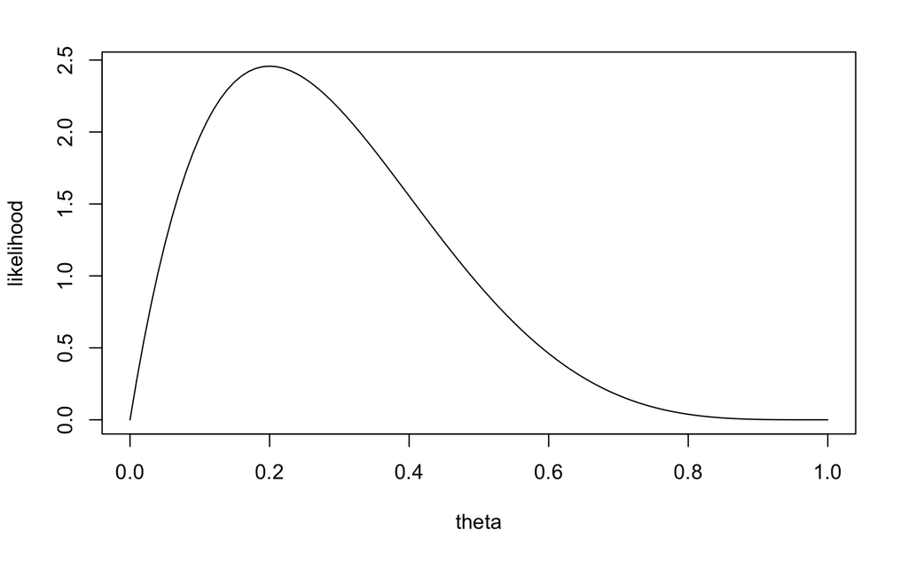

```r
curve(dbeta(theta, shape1 = 2, shape2 = 5), xname='theta', xlab='theta', ylab='likelihood')
```

```r
cat("mean : ", (2/(2+5)))
```

```
mean :  0.2857143
```

## 13.2.2

You watch the last 10 plays of the game, and the outcome is heads 3/10 times. Assuming a binomial likelihood, create a function that determines the likelihood for a given value of the probability of heads, θ. Hence or otherwise, determine the maximum likelihood estimate of θ.

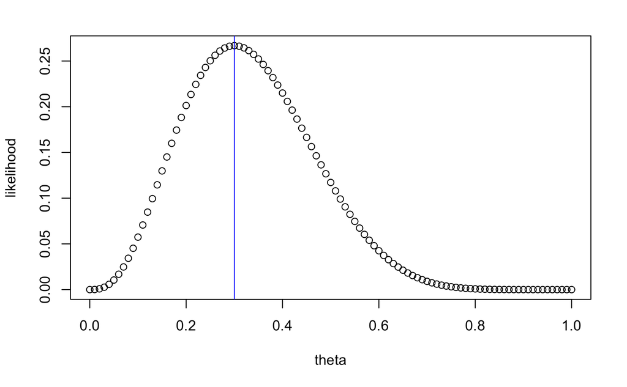

```r
plot(seq(from = 0, to = 1, by = 0.01), dbinom(x = 3, size = 10, prob = seq(from = 0, to = 1, by = 0.01)), xlab='theta', ylab='likelihood')
abline(v=0.3, col="blue")
```

```r
fLikelihood <- function(Z, theta, N){
  return(dbinom(Z, N, theta))
}
```

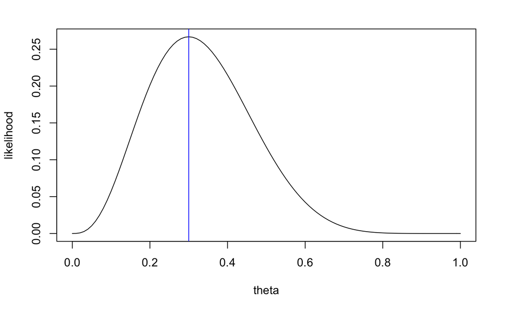

```r
curve(fLikelihood(3, theta, 10), 0, 1, xname="theta", xlab='theta', ylab='likelihood')
abline(v=0.3, col="blue")
```

## 13.2.3

Graph the likelihood × prior. From the graph approximately determine the MAP θ estimate value.

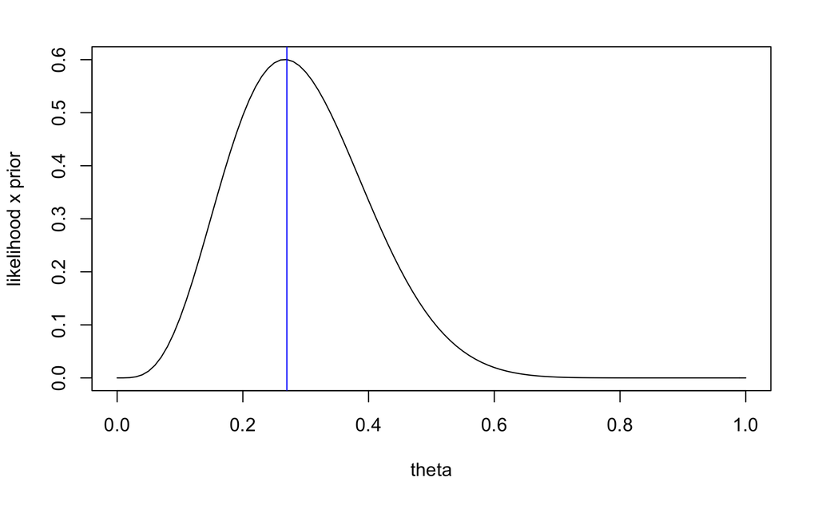

```r
curve(flikelihood(theta, 3, 10) * dbeta(theta, shape1 = 2, shape2 = 5), xname = "theta", ylab = "likelihood x prior")
abline(v=0.27 ,col="blue")
```

```r
fLikelihoodTimesPrior <- function(Z, theta, N, a, b){
  return(fLikelihood(Z, theta, N) * dbeta(theta, a, b))
}
```

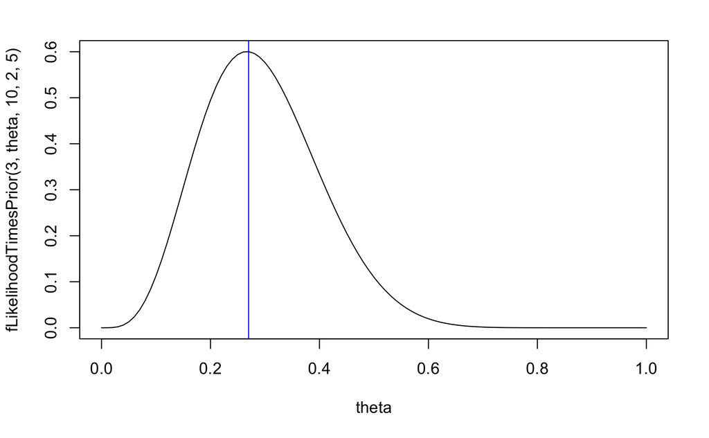

```r
curve(fLikelihoodTimesPrior(3, theta, 10, 2, 5),xname='theta', xlab='theta')
abline(v=0.27 ,col="blue")
```

```r
 optim(0.5, function(theta) -fLikelihoodTimesPrior(3, theta, 10, 2, 5),lower=0, upper=1, method="L-BFGS-B")
```

```
$par
[1] 0.2666675

$value
[1] -0.6004725

$counts
function gradient
      12       12

$convergence
[1] 0

$message
[1] "CONVERGENCE: REL_REDUCTION_OF_F <= FACTR*EPSMCH"
```

## 13.2.4.

By using R’s integrate function find the denominator, and hence graph the posterior pdf.

```r
integrate(function(theta) fLikelihoodTimesPrior(3, theta, 10, 2, 5),lower=0, upper=1)
```

```
0.1648352 with absolute error < 1.8e-15
```

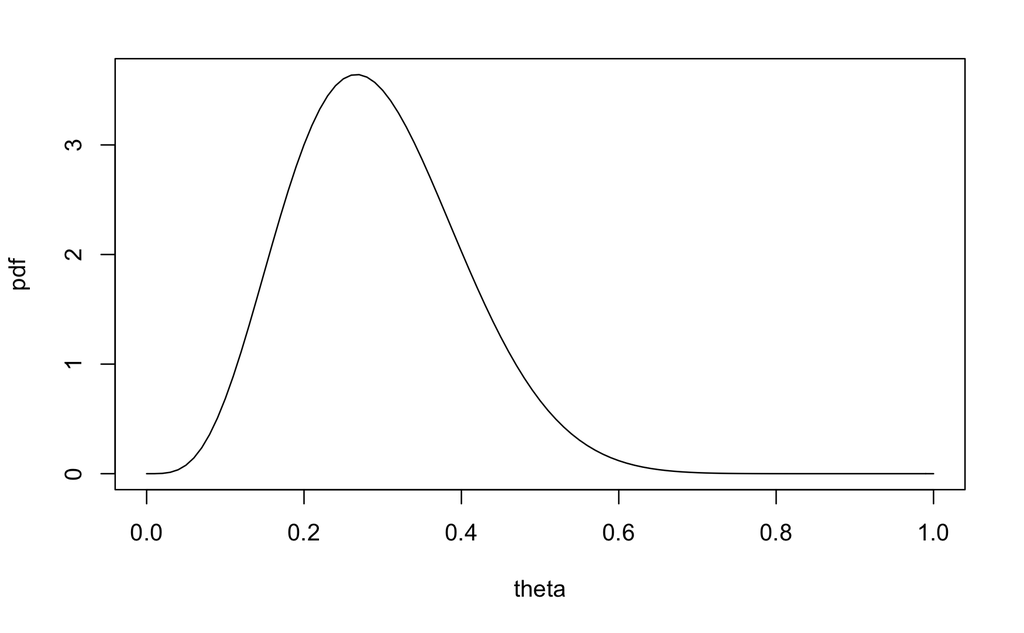

```r
fPosterior <- function(Z, theta, N, a, b){
  aInt = integrate(function(theta1) fLikelihoodTimesPrior(Z, theta1, N, a, b), 0, 1)[[1]]
  return((1 / aInt) * fLikelihood(Z, theta, N) * dbeta(theta, a, b))
}
curve(fPosterior(3, theta, 10, 2, 5), 0, 1, xname = 'theta',
      xlab = 'theta', ylab = 'pdf')
```

## 13.2.5.

Use your posterior to determine your break-even/fair price for participating in the game, assuming that you win £1 if the coin comes up heads, and zero otherwise.

```r
integrate(function(theta) theta * fPosterior(3, theta, 10, 2, 5), 0, 1)
```

```
0.2941176 with absolute error < 3.3e-15
```

## 13.2.8.

Using R’s optim function determine the maximum likelihood estimate of the parameters for Yi = (3,0,4,2,1,2,0,0,5,1). Hint 1: Since R’s optim function does minimisation by default, you will need to put a minus sign in front of the function to maximise it.

```r
fLogLikelihoodHarderAll <- function(lY, theta, phi){
  N0 <- sum(lY == 0)
  N1 <- sum(lY > 0)
  lY1 <- lY[lY > 0]
  aLogLikelihood <- N0 * log((1 - theta) + theta * (1 - phi) ^ 10) +
                    N1 * log(theta) +
                    sum(sapply(lY1, function(Y) log(choose(10, Y) * phi ^ Y * (1 - phi) ^ (10 - Y))))
  return(aLogLikelihood)
}
```

```r
lY <- c(3,0,4,2,1,2,0,0,5,1)
optim(c(0.2, 0.2), function(theta) -fLogLikelihoodHarderAll(lY, theta[1], theta[2]),
      lower = c(0.001, 0.001), upper=c(0.999, 0.999), method="L-BFGS-B")
```

```
$par
[1] 0.7475700 0.2407807

$value
[1] 17.71969

$counts
function gradient
      21       21

$convergence
[1] 0

$message
[1] "CONVERGENCE: REL_REDUCTION_OF_F <= FACTR*EPSMCH"
```

## 13.2.10.

Assuming uniform priors for both θ and φ create a function in R that calculates the unnormalised posterior (the numerator of Bayes’ rule).

```r
fUnnormalisedPosterior <- function(lY, theta, phi){
  return(fLikelihoodHarderAll(lY, theta, phi))
}
```